# Risk Factor Analysis

## Outcome Variable

**Outcome Variable:** stunted

## Predictor Variables

**Intervention Variable:** tr

**Adjustment Set:**

unadjusted

## Stratifying Variables

The analysis was stratified on these variable(s):

- agecat
- studyid
- country

## Data Summary

| agecat | studyid | country | tr | stunted | n_cell | n |
| --- | --- | --- | --- | --- | --- | --- |
| 24 months | ki1000107-Serrinha-VitA | BRAZIL | Control | 0 | 40 | 131 |
| 24 months | ki1000107-Serrinha-VitA | BRAZIL | Control | 1 | 31 | 131 |
| 24 months | ki1000107-Serrinha-VitA | BRAZIL | VitA | 0 | 34 | 131 |
| 24 months | ki1000107-Serrinha-VitA | BRAZIL | VitA | 1 | 26 | 131 |
| 6 months | ki1000107-Serrinha-VitA | BRAZIL | Control | 0 | 10 | 35 |
| 6 months | ki1000107-Serrinha-VitA | BRAZIL | Control | 1 | 6 | 35 |
| 6 months | ki1000107-Serrinha-VitA | BRAZIL | VitA | 0 | 16 | 35 |
| 6 months | ki1000107-Serrinha-VitA | BRAZIL | VitA | 1 | 3 | 35 |
| 24 months | ki1000110-WASH-Bangladesh | BANGLADESH | Control | 0 | 156 | 1187 |
| 24 months | ki1000110-WASH-Bangladesh | BANGLADESH | Control | 1 | 115 | 1187 |
| 24 months | ki1000110-WASH-Bangladesh | BANGLADESH | LNS | 0 | 191 | 1187 |
| 24 months | ki1000110-WASH-Bangladesh | BANGLADESH | LNS | 1 | 116 | 1187 |
| 24 months | ki1000110-WASH-Bangladesh | BANGLADESH | Other | 0 | 357 | 1187 |
| 24 months | ki1000110-WASH-Bangladesh | BANGLADESH | Other | 1 | 252 | 1187 |
| 6 months | ki1000110-WASH-Bangladesh | BANGLADESH | Control | 0 | 132 | 682 |
| 6 months | ki1000110-WASH-Bangladesh | BANGLADESH | Control | 1 | 29 | 682 |
| 6 months | ki1000110-WASH-Bangladesh | BANGLADESH | LNS | 0 | 159 | 682 |
| 6 months | ki1000110-WASH-Bangladesh | BANGLADESH | LNS | 1 | 29 | 682 |
| 6 months | ki1000110-WASH-Bangladesh | BANGLADESH | Other | 0 | 291 | 682 |
| 6 months | ki1000110-WASH-Bangladesh | BANGLADESH | Other | 1 | 42 | 682 |
| 24 months | ki1000111-WASH-Kenya | KENYA | Control | 0 | 527 | 2264 |
| 24 months | ki1000111-WASH-Kenya | KENYA | Control | 1 | 233 | 2264 |
| 24 months | ki1000111-WASH-Kenya | KENYA | LNS | 0 | 354 | 2264 |
| 24 months | ki1000111-WASH-Kenya | KENYA | LNS | 1 | 146 | 2264 |
| 24 months | ki1000111-WASH-Kenya | KENYA | Other | 0 | 684 | 2264 |
| 24 months | ki1000111-WASH-Kenya | KENYA | Other | 1 | 320 | 2264 |
| 6 months | ki1000111-WASH-Kenya | KENYA | Control | 0 | 23 | 74 |
| 6 months | ki1000111-WASH-Kenya | KENYA | Control | 1 | 2 | 74 |
| 6 months | ki1000111-WASH-Kenya | KENYA | LNS | 0 | 12 | 74 |
| 6 months | ki1000111-WASH-Kenya | KENYA | LNS | 1 | 3 | 74 |

[output cut: 185 more lines]

The following strata were considered:

- agecat: 24 months, studyid: iLiNS_DYADM_LNS, country: MALAWI
- agecat: 24 months, studyid: ki1000107-Serrinha-VitA, country: BRAZIL
- agecat: 24 months, studyid: ki1000110-WASH-Bangladesh, country: BANGLADESH
- agecat: 24 months, studyid: ki1000111-WASH-Kenya, country: KENYA
- agecat: 24 months, studyid: ki1000125-AgaKhanUniv, country: PAKISTAN
- agecat: 24 months, studyid: ki1000304-EU, country: INDIA
- agecat: 24 months, studyid: ki1000304-Vitamin-B12, country: INDIA
- agecat: 24 months, studyid: ki1000304-ZnMort, country: INDIA
- agecat: 24 months, studyid: ki1017093b-PROVIDE, country: BANGLADESH
- agecat: 24 months, studyid: ki1066203-TanzaniaChild2, country: TANZANIA, UNITED REPUBLIC OF
- agecat: 24 months, studyid: ki1112895-Burkina Faso Zn, country: BURKINA FASO
- agecat: 24 months, studyid: ki1119695-PROBIT, country: BELARUS
- agecat: 24 months, studyid: ki1126311-ZVITAMBO, country: ZIMBABWE
- agecat: 24 months, studyid: ki1135781-COHORTS, country: GUATEMALA
- agecat: 24 months, studyid: ki1148112-iLiNS-DOSE, country: MALAWI
- agecat: 24 months, studyid: ki1148112-iLiNS-DYAD-M, country: MALAWI
- agecat: 24 months, studyid: ki1148112-LCNI-5, country: MALAWI
- agecat: 24 months, studyid: kiGH5241-JiVitA-3, country: BANGLADESH
- agecat: 24 months, studyid: kiGH5241-JiVitA-4, country: BANGLADESH
- agecat: 6 months, studyid: iLiNS_DYADM_LNS, country: MALAWI
- agecat: 6 months, studyid: ki1000107-Serrinha-VitA, country: BRAZIL
- agecat: 6 months, studyid: ki1000110-WASH-Bangladesh, country: BANGLADESH
- agecat: 6 months, studyid: ki1000111-WASH-Kenya, country: KENYA
- agecat: 6 months, studyid: ki1000125-AgaKhanUniv, country: PAKISTAN
- agecat: 6 months, studyid: ki1000304-EU, country: INDIA
- agecat: 6 months, studyid: ki1000304-VITAMIN-A, country: INDIA
- agecat: 6 months, studyid: ki1000304-Vitamin-B12, country: INDIA
- agecat: 6 months, studyid: ki1000304-ZnMort, country: INDIA
- agecat: 6 months, studyid: ki1000304b-SAS-CompFeed, country: INDIA
- agecat: 6 months, studyid: ki1000304b-SAS-FoodSuppl, country: INDIA
- agecat: 6 months, studyid: ki1017093b-PROVIDE, country: BANGLADESH
- agecat: 6 months, studyid: ki1066203-TanzaniaChild2, country: TANZANIA, UNITED REPUBLIC OF
- agecat: 6 months, studyid: ki1112895-Burkina Faso Zn, country: BURKINA FASO
- agecat: 6 months, studyid: ki1112895-Guatemala BSC, country: GUATEMALA
- agecat: 6 months, studyid: ki1119695-PROBIT, country: BELARUS
- agecat: 6 months, studyid: ki1126311-ZVITAMBO, country: ZIMBABWE
- agecat: 6 months, studyid: ki1135781-COHORTS, country: GUATEMALA
- agecat: 6 months, studyid: ki1148112-iLiNS-DOSE, country: MALAWI
- agecat: 6 months, studyid: ki1148112-iLiNS-DYAD-M, country: MALAWI
- agecat: 6 months, studyid: ki1148112-LCNI-5, country: MALAWI
- agecat: 6 months, studyid: kiGH5241-JiVitA-3, country: BANGLADESH
- agecat: 6 months, studyid: kiGH5241-JiVitA-4, country: BANGLADESH
- agecat: Birth, studyid: iLiNS_DYADM_LNS, country: MALAWI
- agecat: Birth, studyid: ki1000125-AgaKhanUniv, country: PAKISTAN
- agecat: Birth, studyid: ki1000304b-SAS-CompFeed, country: INDIA
- agecat: Birth, studyid: ki1119695-PROBIT, country: BELARUS
- agecat: Birth, studyid: ki1126311-ZVITAMBO, country: ZIMBABWE
- agecat: Birth, studyid: ki1135781-COHORTS, country: GUATEMALA
- agecat: Birth, studyid: ki1148112-iLiNS-DYAD-M, country: MALAWI
- agecat: Birth, studyid: kiGH5241-JiVitA-3, country: BANGLADESH
- agecat: Birth, studyid: kiGH5241-JiVitA-4, country: BANGLADESH

### Dropped Strata

Some strata were dropped due to rare outcomes:

- agecat: 6 months, studyid: ki1000107-Serrinha-VitA, country: BRAZIL
- agecat: 6 months, studyid: ki1000111-WASH-Kenya, country: KENYA
- agecat: 24 months, studyid: ki1000125-AgaKhanUniv, country: PAKISTAN
- agecat: Birth, studyid: ki1000125-AgaKhanUniv, country: PAKISTAN
- agecat: 6 months, studyid: ki1017093b-PROVIDE, country: BANGLADESH
- agecat: 24 months, studyid: ki1017093b-PROVIDE, country: BANGLADESH
- agecat: 24 months, studyid: ki1066203-TanzaniaChild2, country: TANZANIA, UNITED REPUBLIC OF
- agecat: Birth, studyid: ki1148112-iLiNS-DYAD-M, country: MALAWI
- agecat: Birth, studyid: iLiNS_DYADM_LNS, country: MALAWI

## Methods Detail

We’re interested in the causal parameters $E[Y_a]$ for all values of $a \in \mathcal{A}$. These parameters represent the mean outcome if, possibly contrary to fact, we intervened to set all units to have $A=a$. Under the randomization and positivity assumptions, these are identified by the statistical parameters $\psi_a=E_W[E_{Y|A,W}(Y|A=a,W)]$. In addition, we’re interested in the mean of $Y$, $E[Y]$ under no intervention (the observed mean). We will estimate these parameters by using SuperLearner to fit the relevant likelihood factors – $E_{Y|A,W}(Y|A=a,W)$ and $p(A=a|W)$, and then updating our likelihood fit using a joint TMLE.

For unadjusted analyses ($W=\{\}$), initial likelihoods were estimated using Lrnr_glm to estimate the simple $E(Y|A)$ and Lrnr_mean to estimate $p(A)$. For adjusted analyses, a small library containing Lrnr_glmnet, Lrnr_xgboost, and Lrnr_mean was used.

Having estimated these parameters, we will then use the delta method to estimate relative risks and attributable risks relative to a prespecified baseline level of $A$.

# Results Detail

## Results Plots

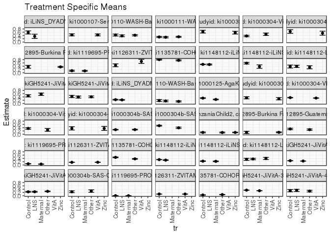

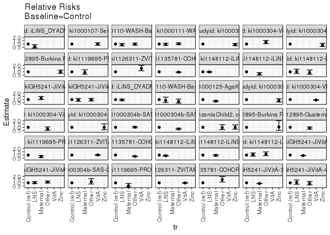

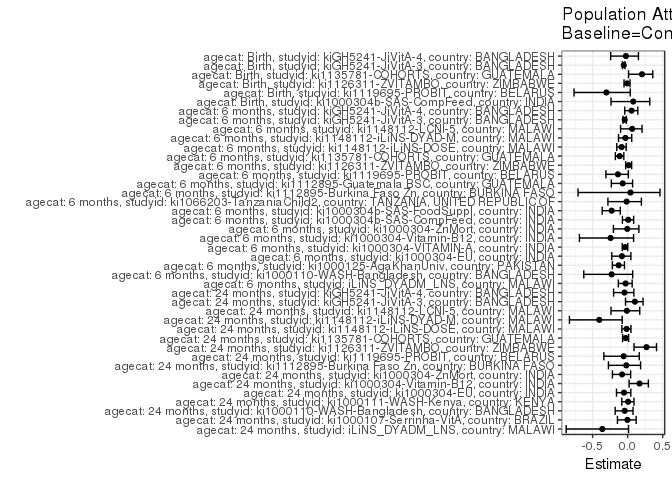

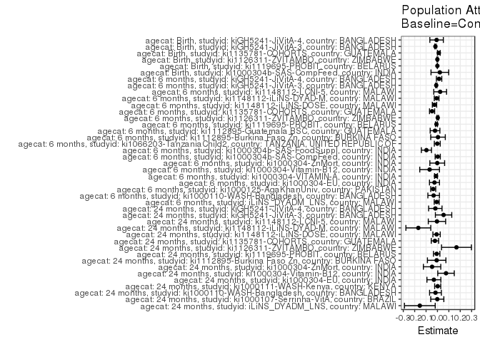

## Results Table

### Parameter: TSM

| agecat | studyid | country | intervention_level | baseline_level | estimate | ci_lower | ci_upper |
| --- | --- | --- | --- | --- | --- | --- | --- |
| Birth | ki1000304b-SAS-CompFeed | INDIA | Control | NA | 0.2428571 | 0.1895042 | 0.2962101 |
| Birth | ki1000304b-SAS-CompFeed | INDIA | Other | NA | 0.2837838 | 0.2079763 | 0.3595913 |
| Birth | ki1119695-PROBIT | BELARUS | Control | NA | 0.0030978 | 0.0020138 | 0.0041818 |
| Birth | ki1119695-PROBIT | BELARUS | Maternal | NA | 0.0016890 | 0.0010564 | 0.0023215 |
| Birth | ki1126311-ZVITAMBO | ZIMBABWE | Control | NA | 0.1043781 | 0.1018333 | 0.1069229 |
| Birth | ki1126311-ZVITAMBO | ZIMBABWE | VitA | NA | 0.1032656 | 0.0988715 | 0.1076597 |
| Birth | ki1135781-COHORTS | GUATEMALA | Control | NA | 0.0466830 | 0.0368868 | 0.0564793 |
| Birth | ki1135781-COHORTS | GUATEMALA | Other | NA | 0.0696629 | 0.0573016 | 0.0820242 |
| Birth | kiGH5241-JiVitA-3 | BANGLADESH | Control | NA | 0.3412682 | 0.3360093 | 0.3465271 |
| Birth | kiGH5241-JiVitA-3 | BANGLADESH | Maternal | NA | 0.3052600 | 0.2999157 | 0.3106042 |
| Birth | kiGH5241-JiVitA-4 | BANGLADESH | Control | NA | 0.3080357 | 0.2378939 | 0.3781775 |
| Birth | kiGH5241-JiVitA-4 | BANGLADESH | LNS | NA | 0.3259912 | 0.2564599 | 0.3955224 |
| Birth | kiGH5241-JiVitA-4 | BANGLADESH | Other | NA | 0.2803235 | 0.2294740 | 0.3311729 |
| 6 months | iLiNS_DYADM_LNS | MALAWI | Control | NA | 0.2336182 | 0.2108528 | 0.2563836 |
| 6 months | iLiNS_DYADM_LNS | MALAWI | LNS | NA | 0.2198795 | 0.1982081 | 0.2415510 |
| 6 months | ki1000110-WASH-Bangladesh | BANGLADESH | Control | NA | 0.1801242 | 0.1207205 | 0.2395280 |
| 6 months | ki1000110-WASH-Bangladesh | BANGLADESH | LNS | NA | 0.1542553 | 0.1025866 | 0.2059240 |
| 6 months | ki1000110-WASH-Bangladesh | BANGLADESH | Other | NA | 0.1261261 | 0.0904423 | 0.1618100 |
| 6 months | ki1000125-AgaKhanUniv | PAKISTAN | Control | NA | 0.3280000 | 0.3023426 | 0.3536574 |
| 6 months | ki1000125-AgaKhanUniv | PAKISTAN | Maternal | NA | 0.2468750 | 0.2251068 | 0.2686432 |
| 6 months | ki1000304-EU | INDIA | Control | NA | 0.3484848 | 0.2820236 | 0.4149461 |
| 6 months | ki1000304-EU | INDIA | Zinc | NA | 0.2909091 | 0.2215130 | 0.3603051 |
| 6 months | ki1000304-VITAMIN-A | INDIA | Control | NA | 0.3573123 | 0.3439900 | 0.3706345 |
| 6 months | ki1000304-VITAMIN-A | INDIA | VitA | NA | 0.3314562 | 0.3184837 | 0.3444286 |
| 6 months | ki1000304-Vitamin-B12 | INDIA | Control | NA | 0.3529412 | 0.3049669 | 0.4009154 |
| 6 months | ki1000304-Vitamin-B12 | INDIA | Other | NA | 0.2656250 | 0.1795962 | 0.3516538 |
| 6 months | ki1000304-ZnMort | INDIA | Control | NA | 0.3604651 | 0.2586376 | 0.4622927 |
| 6 months | ki1000304-ZnMort | INDIA | Zinc | NA | 0.3559322 | 0.2333368 | 0.4785276 |
| 6 months | ki1000304b-SAS-CompFeed | INDIA | Control | NA | 0.2779661 | 0.2597254 | 0.2962068 |
| 6 months | ki1000304b-SAS-CompFeed | INDIA | Other | NA | 0.2826087 | 0.2601334 | 0.3050840 |

[output cut: 63 more lines]

### Parameter: E(Y)

| agecat | studyid | country | intervention_level | baseline_level | estimate | ci_lower | ci_upper |
| --- | --- | --- | --- | --- | --- | --- | --- |
| Birth | ki1000304b-SAS-CompFeed | INDIA | NA | NA | 0.2638889 | 0.1700887 | 0.3576891 |
| Birth | ki1119695-PROBIT | BELARUS | NA | NA | 0.0023768 | 0.0010945 | 0.0036592 |
| Birth | ki1126311-ZVITAMBO | ZIMBABWE | NA | NA | 0.1035430 | 0.0984652 | 0.1086208 |
| Birth | ki1135781-COHORTS | GUATEMALA | NA | NA | 0.0586854 | 0.0428942 | 0.0744767 |
| Birth | kiGH5241-JiVitA-3 | BANGLADESH | NA | NA | 0.3231530 | 0.3154984 | 0.3308077 |
| Birth | kiGH5241-JiVitA-4 | BANGLADESH | NA | NA | 0.3004866 | 0.2649179 | 0.3360553 |
| 6 months | iLiNS_DYADM_LNS | MALAWI | NA | NA | 0.2269400 | 0.1955046 | 0.2583753 |
| 6 months | ki1000110-WASH-Bangladesh | BANGLADESH | NA | NA | 0.1466276 | 0.1200600 | 0.1731951 |
| 6 months | ki1000125-AgaKhanUniv | PAKISTAN | NA | NA | 0.2906475 | 0.2568657 | 0.3244293 |
| 6 months | ki1000304-EU | INDIA | NA | NA | 0.3223140 | 0.2741694 | 0.3704587 |
| 6 months | ki1000304-VITAMIN-A | INDIA | NA | NA | 0.3444976 | 0.3258960 | 0.3630992 |
| 6 months | ki1000304-Vitamin-B12 | INDIA | NA | NA | 0.2839506 | 0.1851417 | 0.3827595 |
| 6 months | ki1000304-ZnMort | INDIA | NA | NA | 0.3586207 | 0.2802882 | 0.4369532 |
| 6 months | ki1000304b-SAS-CompFeed | INDIA | NA | NA | 0.2803890 | 0.2513583 | 0.3094196 |
| 6 months | ki1000304b-SAS-FoodSuppl | INDIA | NA | NA | 0.4253521 | 0.3738504 | 0.4768538 |
| 6 months | ki1066203-TanzaniaChild2 | TANZANIA, UNITED REPUBLIC OF | NA | NA | 0.1089631 | 0.0941772 | 0.1237489 |
| 6 months | ki1112895-Burkina Faso Zn | BURKINA FASO | NA | NA | 0.1158730 | 0.0908597 | 0.1408863 |
| 6 months | ki1112895-Guatemala BSC | GUATEMALA | NA | NA | 0.3027523 | 0.2416221 | 0.3638824 |
| 6 months | ki1119695-PROBIT | BELARUS | NA | NA | 0.0637241 | 0.0488374 | 0.0786108 |
| 6 months | ki1126311-ZVITAMBO | ZIMBABWE | NA | NA | 0.1658951 | 0.1576266 | 0.1741635 |
| 6 months | ki1135781-COHORTS | GUATEMALA | NA | NA | 0.4173820 | 0.3857058 | 0.4490581 |
| 6 months | ki1148112-iLiNS-DOSE | MALAWI | NA | NA | 0.3020725 | 0.2815825 | 0.3225626 |
| 6 months | ki1148112-iLiNS-DYAD-M | MALAWI | NA | NA | 0.2264334 | 0.2008493 | 0.2520176 |
| 6 months | ki1148112-LCNI-5 | MALAWI | NA | NA | 0.3682956 | 0.3356382 | 0.4009530 |
| 6 months | kiGH5241-JiVitA-3 | BANGLADESH | NA | NA | 0.2513720 | 0.2432392 | 0.2595048 |
| 6 months | kiGH5241-JiVitA-4 | BANGLADESH | NA | NA | 0.2534389 | 0.2390992 | 0.2677787 |
| 24 months | iLiNS_DYADM_LNS | MALAWI | NA | NA | 0.4285714 | 0.2622297 | 0.5949132 |
| 24 months | ki1000107-Serrinha-VitA | BRAZIL | NA | NA | 0.4351145 | 0.3498912 | 0.5203378 |
| 24 months | ki1000110-WASH-Bangladesh | BANGLADESH | NA | NA | 0.4069082 | 0.3789496 | 0.4348667 |
| 24 months | ki1000111-WASH-Kenya | KENYA | NA | NA | 0.3087456 | 0.2897118 | 0.3277794 |
| 24 months | ki1000304-EU | INDIA | NA | NA | 0.6007905 | 0.5403247 | 0.6612563 |
| 24 months | ki1000304-Vitamin-B12 | INDIA | NA | NA | 0.4436090 | 0.3588568 | 0.5283613 |
| 24 months | ki1000304-ZnMort | INDIA | NA | NA | 0.5928571 | 0.5111821 | 0.6745321 |
| 24 months | ki1112895-Burkina Faso Zn | BURKINA FASO | NA | NA | 0.3567151 | 0.3292432 | 0.3841871 |
| 24 months | ki1119695-PROBIT | BELARUS | NA | NA | 0.1189061 | 0.0738430 | 0.1639691 |
| 24 months | ki1126311-ZVITAMBO | ZIMBABWE | NA | NA | 0.6216216 | 0.4631969 | 0.7800464 |
| 24 months | ki1135781-COHORTS | GUATEMALA | NA | NA | 0.7791045 | 0.7346141 | 0.8235949 |
| 24 months | ki1148112-iLiNS-DOSE | MALAWI | NA | NA | 0.5038660 | 0.4686650 | 0.5390669 |
| 24 months | ki1148112-iLiNS-DYAD-M | MALAWI | NA | NA | 0.4153846 | 0.2946537 | 0.5361155 |
| 24 months | ki1148112-LCNI-5 | MALAWI | NA | NA | 0.3740260 | 0.3256297 | 0.4224222 |
| 24 months | kiGH5241-JiVitA-3 | BANGLADESH | NA | NA | 0.5204082 | 0.4200084 | 0.6208080 |
| 24 months | kiGH5241-JiVitA-4 | BANGLADESH | NA | NA | 0.4078467 | 0.3734066 | 0.4422868 |

### Parameter: RR

| agecat | studyid | country | intervention_level | baseline_level | estimate | ci_lower | ci_upper |
| --- | --- | --- | --- | --- | --- | --- | --- |
| Birth | ki1000304b-SAS-CompFeed | INDIA | Control | Control | 1.0000000 | 1.0000000 | 1.0000000 |
| Birth | ki1000304b-SAS-CompFeed | INDIA | Other | Control | 1.1685215 | 0.8266011 | 1.6518759 |
| Birth | ki1119695-PROBIT | BELARUS | Control | Control | 1.0000000 | 1.0000000 | 1.0000000 |
| Birth | ki1119695-PROBIT | BELARUS | Maternal | Control | 0.5452096 | 0.3264144 | 0.9106631 |
| Birth | ki1126311-ZVITAMBO | ZIMBABWE | Control | Control | 1.0000000 | 1.0000000 | 1.0000000 |
| Birth | ki1126311-ZVITAMBO | ZIMBABWE | VitA | Control | 0.9893416 | 0.9419935 | 1.0390697 |
| Birth | ki1135781-COHORTS | GUATEMALA | Control | Control | 1.0000000 | 1.0000000 | 1.0000000 |
| Birth | ki1135781-COHORTS | GUATEMALA | Other | Control | 1.4922531 | 1.1336867 | 1.9642281 |
| Birth | kiGH5241-JiVitA-3 | BANGLADESH | Control | Control | 1.0000000 | 1.0000000 | 1.0000000 |
| Birth | kiGH5241-JiVitA-3 | BANGLADESH | Maternal | Control | 0.8944869 | 0.8738617 | 0.9155990 |
| Birth | kiGH5241-JiVitA-4 | BANGLADESH | Control | Control | 1.0000000 | 1.0000000 | 1.0000000 |
| Birth | kiGH5241-JiVitA-4 | BANGLADESH | LNS | Control | 1.0582902 | 0.7746526 | 1.4457813 |
| Birth | kiGH5241-JiVitA-4 | BANGLADESH | Other | Control | 0.9100355 | 0.6801878 | 1.2175531 |
| 6 months | iLiNS_DYADM_LNS | MALAWI | Control | Control | 1.0000000 | 1.0000000 | 1.0000000 |
| 6 months | iLiNS_DYADM_LNS | MALAWI | LNS | Control | 0.9411916 | 0.8193786 | 1.0811139 |
| 6 months | ki1000110-WASH-Bangladesh | BANGLADESH | Control | Control | 1.0000000 | 1.0000000 | 1.0000000 |
| 6 months | ki1000110-WASH-Bangladesh | BANGLADESH | LNS | Control | 0.8563830 | 0.5352078 | 1.3702936 |
| 6 months | ki1000110-WASH-Bangladesh | BANGLADESH | Other | Control | 0.7002175 | 0.4534432 | 1.0812918 |
| 6 months | ki1000125-AgaKhanUniv | PAKISTAN | Control | Control | 1.0000000 | 1.0000000 | 1.0000000 |
| 6 months | ki1000125-AgaKhanUniv | PAKISTAN | Maternal | Control | 0.7526677 | 0.6689784 | 0.8468265 |
| 6 months | ki1000304-EU | INDIA | Control | Control | 1.0000000 | 1.0000000 | 1.0000000 |
| 6 months | ki1000304-EU | INDIA | Zinc | Control | 0.8347826 | 0.6150830 | 1.1329561 |
| 6 months | ki1000304-VITAMIN-A | INDIA | Control | Control | 1.0000000 | 1.0000000 | 1.0000000 |
| 6 months | ki1000304-VITAMIN-A | INDIA | VitA | Control | 0.9276372 | 0.8788254 | 0.9791602 |
| 6 months | ki1000304-Vitamin-B12 | INDIA | Control | Control | 1.0000000 | 1.0000000 | 1.0000000 |
| 6 months | ki1000304-Vitamin-B12 | INDIA | Other | Control | 0.7526042 | 0.5296936 | 1.0693220 |
| 6 months | ki1000304-ZnMort | INDIA | Control | Control | 1.0000000 | 1.0000000 | 1.0000000 |
| 6 months | ki1000304-ZnMort | INDIA | Zinc | Control | 0.9874248 | 0.6324741 | 1.5415774 |
| 6 months | ki1000304b-SAS-CompFeed | INDIA | Control | Control | 1.0000000 | 1.0000000 | 1.0000000 |
| 6 months | ki1000304b-SAS-CompFeed | INDIA | Other | Control | 1.0167020 | 0.9170953 | 1.1271271 |

[output cut: 63 more lines]

### Parameter: PAR

| agecat | studyid | country | intervention_level | baseline_level | estimate | ci_lower | ci_upper |
| --- | --- | --- | --- | --- | --- | --- | --- |
| Birth | ki1000304b-SAS-CompFeed | INDIA | Control | NA | 0.0210317 | -0.0567751 | 0.0988386 |
| Birth | ki1119695-PROBIT | BELARUS | Control | NA | -0.0007210 | -0.0013920 | -0.0000499 |
| Birth | ki1126311-ZVITAMBO | ZIMBABWE | Control | NA | -0.0008351 | -0.0052292 | 0.0035591 |
| Birth | ki1135781-COHORTS | GUATEMALA | Control | NA | 0.0120024 | -0.0003829 | 0.0243877 |
| Birth | kiGH5241-JiVitA-3 | BANGLADESH | Control | NA | -0.0181152 | -0.0236976 | -0.0125328 |
| Birth | kiGH5241-JiVitA-4 | BANGLADESH | Control | NA | -0.0075491 | -0.0667305 | 0.0516323 |
| 6 months | iLiNS_DYADM_LNS | MALAWI | Control | NA | -0.0066783 | -0.0283558 | 0.0149993 |
| 6 months | ki1000110-WASH-Bangladesh | BANGLADESH | Control | NA | -0.0334967 | -0.0841775 | 0.0171842 |
| 6 months | ki1000125-AgaKhanUniv | PAKISTAN | Control | NA | -0.0373525 | -0.0593276 | -0.0153774 |
| 6 months | ki1000304-EU | INDIA | Control | NA | -0.0261708 | -0.0699469 | 0.0176053 |
| 6 months | ki1000304-VITAMIN-A | INDIA | Control | NA | -0.0128146 | -0.0257969 | 0.0001676 |
| 6 months | ki1000304-Vitamin-B12 | INDIA | Control | NA | -0.0689906 | -0.1553715 | 0.0173904 |
| 6 months | ki1000304-ZnMort | INDIA | Control | NA | -0.0018444 | -0.0666922 | 0.0630033 |
| 6 months | ki1000304b-SAS-CompFeed | INDIA | Control | NA | 0.0024229 | -0.0201633 | 0.0250091 |
| 6 months | ki1000304b-SAS-FoodSuppl | INDIA | Control | NA | -0.0968701 | -0.1412098 | -0.0525304 |
| 6 months | ki1066203-TanzaniaChild2 | TANZANIA, UNITED REPUBLIC OF | Control | NA | -0.0016251 | -0.0274171 | 0.0241668 |
| 6 months | ki1112895-Burkina Faso Zn | BURKINA FASO | Control | NA | 0.0047619 | -0.0593531 | 0.0688769 |
| 6 months | ki1112895-Guatemala BSC | GUATEMALA | Control | NA | -0.0213218 | -0.0639341 | 0.0212905 |
| 6 months | ki1119695-PROBIT | BELARUS | Control | NA | -0.0088293 | -0.0175909 | -0.0000676 |
| 6 months | ki1126311-ZVITAMBO | ZIMBABWE | Control | NA | 0.0025339 | -0.0046584 | 0.0097262 |
| 6 months | ki1135781-COHORTS | GUATEMALA | Control | NA | -0.0472198 | -0.0697055 | -0.0247340 |
| 6 months | ki1148112-iLiNS-DOSE | MALAWI | Control | NA | -0.0260525 | -0.0446817 | -0.0074232 |
| 6 months | ki1148112-iLiNS-DYAD-M | MALAWI | Control | NA | -0.0071848 | -0.0278326 | 0.0134630 |
| 6 months | ki1148112-LCNI-5 | MALAWI | Control | NA | 0.0237980 | -0.0323421 | 0.0799381 |
| 6 months | kiGH5241-JiVitA-3 | BANGLADESH | Control | NA | -0.0107394 | -0.0163865 | -0.0050923 |
| 6 months | kiGH5241-JiVitA-4 | BANGLADESH | Control | NA | 0.0142389 | -0.0094173 | 0.0378952 |
| 24 months | iLiNS_DYADM_LNS | MALAWI | Control | NA | -0.1547619 | -0.2898701 | -0.0196537 |
| 24 months | ki1000107-Serrinha-VitA | BRAZIL | Control | NA | -0.0015052 | -0.0591548 | 0.0561444 |
| 24 months | ki1000110-WASH-Bangladesh | BANGLADESH | Control | NA | -0.0174461 | -0.0690681 | 0.0341760 |
| 24 months | ki1000111-WASH-Kenya | KENYA | Control | NA | 0.0021666 | -0.0245833 | 0.0289165 |
| 24 months | ki1000304-EU | INDIA | Control | NA | -0.0312095 | -0.0923748 | 0.0299559 |
| 24 months | ki1000304-Vitamin-B12 | INDIA | Control | NA | 0.0751880 | 0.0027436 | 0.1476324 |
| 24 months | ki1000304-ZnMort | INDIA | Control | NA | -0.0471429 | -0.1234437 | 0.0291580 |
| 24 months | ki1112895-Burkina Faso Zn | BURKINA FASO | Control | NA | -0.0069212 | -0.0880717 | 0.0742293 |
| 24 months | ki1119695-PROBIT | BELARUS | Control | NA | -0.0067624 | -0.0348609 | 0.0213361 |
| 24 months | ki1126311-ZVITAMBO | ZIMBABWE | Control | NA | 0.1670762 | 0.0358016 | 0.2983507 |
| 24 months | ki1135781-COHORTS | GUATEMALA | Control | NA | -0.0220651 | -0.0543790 | 0.0102488 |
| 24 months | ki1148112-iLiNS-DOSE | MALAWI | Control | NA | -0.0077619 | -0.0399057 | 0.0243818 |
| 24 months | ki1148112-iLiNS-DYAD-M | MALAWI | Control | NA | -0.1679487 | -0.2769561 | -0.0589413 |
| 24 months | ki1148112-LCNI-5 | MALAWI | Control | NA | -0.0043524 | -0.0804935 | 0.0717887 |
| 24 months | kiGH5241-JiVitA-3 | BANGLADESH | Control | NA | 0.0537415 | -0.0181280 | 0.1256110 |
| 24 months | kiGH5241-JiVitA-4 | BANGLADESH | Control | NA | -0.0187267 | -0.0775465 | 0.0400931 |

### Parameter: PAF

| agecat | studyid | country | intervention_level | baseline_level | estimate | ci_lower | ci_upper |
| --- | --- | --- | --- | --- | --- | --- | --- |
| Birth | ki1000304b-SAS-CompFeed | INDIA | Control | NA | 0.0796992 | -0.2367987 | 0.3152051 |
| Birth | ki1119695-PROBIT | BELARUS | Control | NA | -0.3033298 | -0.7644562 | 0.0372849 |
| Birth | ki1126311-ZVITAMBO | ZIMBABWE | Control | NA | -0.0080648 | -0.0517659 | 0.0338204 |
| Birth | ki1135781-COHORTS | GUATEMALA | Control | NA | 0.2045209 | 0.0133548 | 0.3586478 |
| Birth | kiGH5241-JiVitA-3 | BANGLADESH | Control | NA | -0.0560577 | -0.0744788 | -0.0379523 |
| Birth | kiGH5241-JiVitA-4 | BANGLADESH | Control | NA | -0.0251229 | -0.2421633 | 0.1539945 |
| 6 months | iLiNS_DYADM_LNS | MALAWI | Control | NA | -0.0294274 | -0.1326579 | 0.0643946 |
| 6 months | ki1000110-WASH-Bangladesh | BANGLADESH | Control | NA | -0.2284472 | -0.6257166 | 0.0717432 |
| 6 months | ki1000125-AgaKhanUniv | PAKISTAN | Control | NA | -0.1285149 | -0.2179576 | -0.0456405 |
| 6 months | ki1000304-EU | INDIA | Control | NA | -0.0811966 | -0.2259316 | 0.0464508 |
| 6 months | ki1000304-VITAMIN-A | INDIA | Control | NA | -0.0371981 | -0.0770578 | 0.0011866 |
| 6 months | ki1000304-Vitamin-B12 | INDIA | Control | NA | -0.2429668 | -0.6879245 | 0.0846946 |
| 6 months | ki1000304-ZnMort | INDIA | Control | NA | -0.0051431 | -0.2032552 | 0.1603504 |
| 6 months | ki1000304b-SAS-CompFeed | INDIA | Control | NA | 0.0086411 | -0.0745225 | 0.0853682 |
| 6 months | ki1000304b-SAS-FoodSuppl | INDIA | Control | NA | -0.2277410 | -0.3634831 | -0.1055128 |
| 6 months | ki1066203-TanzaniaChild2 | TANZANIA, UNITED REPUBLIC OF | Control | NA | -0.0149146 | -0.2814893 | 0.1962074 |
| 6 months | ki1112895-Burkina Faso Zn | BURKINA FASO | Control | NA | 0.0410959 | -0.7074745 | 0.4614871 |
| 6 months | ki1112895-Guatemala BSC | GUATEMALA | Control | NA | -0.0704265 | -0.2326038 | 0.0704127 |
| 6 months | ki1119695-PROBIT | BELARUS | Control | NA | -0.1385549 | -0.3101846 | 0.0105918 |
| 6 months | ki1126311-ZVITAMBO | ZIMBABWE | Control | NA | 0.0152741 | -0.0283588 | 0.0570556 |
| 6 months | ki1135781-COHORTS | GUATEMALA | Control | NA | -0.1131333 | -0.1750673 | -0.0544637 |
| 6 months | ki1148112-iLiNS-DOSE | MALAWI | Control | NA | -0.0862457 | -0.1553920 | -0.0212376 |
| 6 months | ki1148112-iLiNS-DYAD-M | MALAWI | Control | NA | -0.0317303 | -0.1302597 | 0.0582099 |
| 6 months | ki1148112-LCNI-5 | MALAWI | Control | NA | 0.0646165 | -0.1009505 | 0.2052847 |
| 6 months | kiGH5241-JiVitA-3 | BANGLADESH | Control | NA | -0.0427230 | -0.0664323 | -0.0195408 |
| 6 months | kiGH5241-JiVitA-4 | BANGLADESH | Control | NA | 0.0561829 | -0.0418598 | 0.1449994 |
| 24 months | iLiNS_DYADM_LNS | MALAWI | Control | NA | -0.3611111 | -0.8761569 | 0.0125434 |
| 24 months | ki1000107-Serrinha-VitA | BRAZIL | Control | NA | -0.0034594 | -0.1456215 | 0.1210617 |
| 24 months | ki1000110-WASH-Bangladesh | BANGLADESH | Control | NA | -0.0428747 | -0.1777945 | 0.0765896 |
| 24 months | ki1000111-WASH-Kenya | KENYA | Control | NA | 0.0070175 | -0.0835152 | 0.0899858 |
| 24 months | ki1000304-EU | INDIA | Control | NA | -0.0519474 | -0.1591648 | 0.0453530 |
| 24 months | ki1000304-Vitamin-B12 | INDIA | Control | NA | 0.1694915 | 0.0209390 | 0.2955042 |
| 24 months | ki1000304-ZnMort | INDIA | Control | NA | -0.0795181 | -0.2173265 | 0.0426897 |
| 24 months | ki1112895-Burkina Faso Zn | BURKINA FASO | Control | NA | -0.0194027 | -0.2742800 | 0.1844949 |
| 24 months | ki1119695-PROBIT | BELARUS | Control | NA | -0.0568717 | -0.3391997 | 0.1659364 |
| 24 months | ki1126311-ZVITAMBO | ZIMBABWE | Control | NA | 0.2687747 | 0.0910263 | 0.4117647 |
| 24 months | ki1135781-COHORTS | GUATEMALA | Control | NA | -0.0283211 | -0.0718833 | 0.0134707 |
| 24 months | ki1148112-iLiNS-DOSE | MALAWI | Control | NA | -0.0154047 | -0.0822941 | 0.0473506 |
| 24 months | ki1148112-iLiNS-DYAD-M | MALAWI | Control | NA | -0.4043210 | -0.8302142 | -0.0775336 |
| 24 months | ki1148112-LCNI-5 | MALAWI | Control | NA | -0.0116366 | -0.2371380 | 0.1727611 |
| 24 months | kiGH5241-JiVitA-3 | BANGLADESH | Control | NA | 0.1032680 | -0.0303704 | 0.2195735 |
| 24 months | kiGH5241-JiVitA-4 | BANGLADESH | Control | NA | -0.0459161 | -0.2005219 | 0.0887793 |